# Topic 4; Trees: Classification and Regression Trees (CART), Bagging, Random Forest, Boosting

Jonas Mikkelsen

30/5/2021

# Trees

Trees is a method that can help with the selection of appropriate basis functions. Trees are supervised algorithms that can be used for classification and regression. Tree based methods partition the sample space into hyper-rectangles and then fit a simple model to each.

## Classification and Regression Trees (CART)

The CART output is typically displayed like a tree. Hereby the name. The algorithm itself needs to automatically decide on the split points for the basis functions. It starts by looking for the split point that gives us the greatest increase in fit. That is,

$$\begin{align*}
\underset{s}{\min}\left(\underset{c_1}{\min}\sum_{x_i<s}(y_i-c_1)^2+\underset{c_2}
{\min}\sum_{x_i\geq s}(y_i-c_2)^2\right)
\end{align*}$$

Hence, it finds the splitpoint $s$ such that the residuals are minimized before and after the splitpoint. Recall that because $c_1$ and $c_2$ are constants, we have that $\hat{y}_1 = \underset{c_1}{\min}\sum_{x_i<s}(y_i-c_1)^2$ and $\hat{y}_2 = \underset{c_2}{\min}\sum_{x_i\geq s}(y_i-c_2)^2$ where $\hat{y}_1,\hat{y}_2$ denotes the mean values for $y_i$ such that $x_i<s$ and $x_i\geq s$. Hence we only need to find the cutpoint. When this is found, we get the basis function $b_1(x_i) = I(x_i<s)$ and $b_2(x_i) = I(x_i\geq s)$, where $I$ is the indicator function. This is the same as fitting

$$\begin{align*}
y_i = \beta_1b_1(x_i)+\beta_2b_2(x_i)
\end{align*}$$

Similarly, when we have decided on the first cutpoint, we now look for a new cutpoint in the two separated parts of the data, find two candidates for new cutpoints, and pick the ones that minimizes the most. This is repeated until either a fixed number of cutpoints is obtained or when the error term is not improved much.

Multivariate is similar. First, obtain the first cutpoint for each of $p$ variables. Then pick the one that minimizes the loss function, similar to before. Procedure is known as recursive binary splitting. Mathematically, suppose we have $p$ explanatory variables $X_1,\ldots,X_p$. Let $s$ be the cutpoint. Define

$$\begin{align*}
R_1(j,s) = \{X|X_j<s\},\quad R_2(j,s) = \{X|X_j\geq s\}
\end{align*}$$

Then the first cutpoint in CART solves

$$\begin{align*}
\underset{j,s}{\min}\left(\sum_{i|x_i\in R_1(j,s)}(y_i-\hat{y}_{R_1})^2+
\sum_{i|x_i\in R_2(j,s)}(y_i-\hat{y}_{R_2})^2\right)
\end{align*}$$

where the mean has been substituted in. Process is repeated for each subregion.

### Pruning

A larger tree would fit the data better, while a small tree may not fit the data well, i.e. high bias. Bias/Variance trade off. Pruning tries to do this. It grows a large tree and then eliminate nodes that do not add much to the fit.

The idea is to find a subtree that leads to a lower generalization error rate. With test data and a small tree, we can evaluate the error for each subtree, but if the tree is large, it is not efficient since there are many subtrees. To overcome this, it is possible to weakest link pruning (greedy way), which introduces a loss-penalty formulation to pruning.

Weakest link pruning considers the optimization problem;

For $\alpha\geq 0$, find the subtree that minimizes

$$\begin{align*}
C_\alpha(T) = \sum_{m=1}^{|T|}\sum_{i|x_i\in R_m}(y_i-\hat{y}_{R_m})^2+\alpha|T|
\end{align*}$$

$|T|$ is the number of terminal nodes of tree T, $R_m$ is the region corresponding to the $m'th$ terminal node. $\alpha$ is a tuning parameter. Determines penalty of growing a larger tree. $\alpha = 0$ implies the subtree is the complete tree. Increasing $\alpha$ is an increase in cost of growing a large tree, such that small trees will be selected.

To find the optimal tree, we succesively collapse the internal node which produces the smallest per node increase in the loss function. Repeated until we have a single node tree. Gives a sequence of subtrees. Mathematical result states that there exists a unique smallest subtree that minimizes cost complexity. It is possible to choose $\alpha$ with a validation set or cross validation.

The algorithm is thus given by;

1. Use recursive binary splitting to grow a large tree on the training data. Stop when each terminal node has fewer than some minimum number of observations
2. Apply cost complexity pruning to the large tree in order to obtain a sequence of best subtrees as a function of $\alpha$
3. Use K-fold cross validation to choose $\alpha$.
4. Return the subtree from step $2$ that corresponds to the chosen value of $\alpha$.

To use this for classification, we need to modify the loss function. Usually a majority vote is introduced. It is possible to use missclassification error, gini index or cross-entropy. For pruning, missclassification is preferred.

Let $m$ present the region $R_m$ containing $N_m$ observations. Let

$$\begin{align*}
\hat{p}_{m,k}=\frac{1}{N_m}\sum_{x_i\in R_m}I(y_i=k)
\end{align*}$$

be the proportion of class $k$ observations in node $m$. We classify observations in $m$ to class $k(m)=\underset{k}{\arg \max}\hat{p}_{m,k}$. Loss functions given by

Missclassification error:

$$\begin{align*}
E = \frac{1}{N_m}\sum_{x_i\in R_m}I(y_i\neq k(m)) = 1-\hat{p}_{m,k}
\end{align*}$$

Gini index:

$$\begin{align*}
G = \sum_{k=1}^K\hat{p}_{m,k}(1-\hat{p}_{m,k})
\end{align*}$$

Cross-entropy:

$$\begin{align*}
D = -\sum_{k=1}^K \hat{p}_{m,k}\log(\hat{p}_{m,k})
\end{align*}$$

G and D take small values if all $\hat{p}_{m,k}$’s are close to zero or to one.

### Considerations

Tree based methods are simple, useful for interpretation. Does variable selection. Can handle categorical predictors. However, trees are unstable. Some observations can dramatically affect which variables are selected and the precise values used for partitioning the data, implying that all subsequent partitions are affected.

This is related to overfitting, hard to generalize the result. If the data is kind of linear, trees is not very useful, because they produce rectangles. On the other hand, trees are great if the data looks rectangular and not linear. Thus it depends on the data.

## Bagging

Bagging stands for bootstrap aggregation. General purpose is reducing the variance of an algorithm. Because taking the average reduces the variance, we can combine many weak algorithms to produce a powerful committee. In the perfect world, we would like to have many random samples, constructing a tree for each and the take the average. Eliminates the noise. Getting multiple samples is not always possible, so we use bootstrap. Thus bagging is the algorithm;

Assume that we have training data with $n$ observations and a categorical response. Then

1. Take a random sample of size $n$ with replacement from the original data (Bootstrap sample)
2. Construct a classification tree without pruning
3. Assign a class to each terminal node
4. Repeat steps 1-3 $B$ times, where $B$ is a large number
5. For each observation in the dataset, count the number of times over trees that is classified in each category.
6. Assign each observation to a final class by a majority vote over the set of trees.

Hence we calculate $B$ trees, $\hat{f}^1(x),\hat{f}^2(x),\ldots,\hat{f}^B(x)$ using the different bootstrap sample. For classification, a majority vote is used

$$\begin{align*}
\hat{f}_{avg}(x) = \underset{k}{\arg \max}\sum_{j=1}^BI(\hat{f}^j(x) = k)
\end{align*}$$

while taking an average for regression;

$$\begin{align*}
\hat{f}_{avg}(x) = \frac{1}{B}\sum_{j=1}^B\hat{f}^j(x)
\end{align*}$$

While overfitting is possible, the many replications reduces the variance and thus avoids overfitting. In practice, B is selected sufficiently large such that the error is low.

#### Out-of-bag error estimation

When bootstrapping, approximately $2/3$ of the data is used in each sample. Out- of-bag error estimation, (OOB) error estimation, then predicts the response of an observation using the trees constructed with samples that do not contain that observation. Hence OOB error estimator is a valid estimate of the test error. More efficient than validation set or cross-validation since it can be computed almost on the side when doing the bagging itself.

### Considerations

Bagging results in improved accuracy over a single, but loses interpretation. It is no longer clear which variables is the most important, we take the average.

It is possible to compute measure of variable importance by storing the total amount that the RSS (Or gini index in classification) decreases due to splits for a given predictor. Large values then indicates an important predictor.

In practice, bagging can generate fitted values that often reproduce the data well. Lot of data is shared from each tree, meaning the fitted values are not independent. Averaging is not as effective as it can be. Still, if trees do not fit the data, bagging will also be bad.

## Random Forest

Random forest looks to lower the dependence in the data and predictors in all the fitted trees. For instance, if one predictor is really strong, then most of the trees will use this strong predictor, thus similar trees, i.e. highly correlated trees and thus variance reduction is not as great as we want it to be. Random Forest is an algorithm that improves over bagging by decorrelating the predictors. The setup is the same, averaging a large number of trees, but random forest randomly select a subset of the predictors in each split. The algorithm has the form;

Assume that we have training data with $n$ observations and a categorical response. Then

1. Take a random sample of size $n$ with replacement from the data.
2. Take a random sample of size $m<p$ where $p$ is the number of predictors without replacement of the predictors.
3. Construct the first recursive partition of the data.
4. Repeat step 2 for each subsequent split until the tree is as large as desired. No pruning. Assign a class to each terminal node.
5. Repeat steps 1-4 $B$ times, $B$ being a large real number.
6. Assign each case to a category by a majority vote over the set of trees obtained.

In the case $m = p$ we have bagging again. Random forest does not overfit if we increase $B$, i.e. many replications. However, still no interpretation. Small $m$ works well if many of the predictors are correlated.

## Boosting

Boosting is another approach for improving the prediction of algorithms. Boosting is kind of similar to Bagging and Random Forest in the sense that they use many outputs of weak classifiers to form a powerful classifier, but fundamentally, boosting is different.

At each iteration in boosting, it works with the entire data set, i.e. it uses all the sample and all the predictors. In each iteration, the observations that are misclassified/poorly fitted are given more relative weight. This is not present in random forest. In the end, the final fitted values are a linear combination over a large set of earlier fitting attempts, but the combination is not a simple average as in random forest. The algorithm is given by;

1. Set $\hat{f}(x) = 0$ and $r_i = y_i$ for each $i$ in the training set.
2. for $b=1,\ldots, B$, do
- Fit a tree $\hat{f}^b$ with $d$ splits to the training data $(X,r)$, where $r$ is the residuals.
- Update $\hat{f}$ by adding a shrunken version of the new tree;

$$\begin{align*}
\hat{f}(x) \leftarrow \hat{f}(x) + \lambda\hat{f}^b(x)
\end{align*}$$

- Update residuals;

$$\begin{align*}
r_i \leftarrow r_i - \lambda\hat{f}^b(x_i)
\end{align*}$$

1. Output the boosted model
   $$\begin{align*}
   \hat{f}(x) = \sum_{b=1}^B \lambda\hat{f}^b(x)
   \end{align*}$$

Hence each fitting attempt is undertaken by a classifier using the residuals from the previous iteration. Hence boosting will pay relatively more attention in the next iteration to the cases that were poorly predicted, i.e. the ones with large residuals. Fitted values from each iteration are combined as a weighted sum.

Because the growth of a particular tree takes into account the previously grown trees, smaller trees are typically sufficient for this method.

### Considerations

Boosting has three tuning parameters.

1. The number of trees $B$: Boosting can overfit if $B$ is too large. We end up explaining the noise if $B$ is too large.
2. Shrinkage parameter $\lambda$: Controls the rate at which the boosting learns. Typically low values such as $0.01$ and $0.001$. Right choice depends on the problem. Very small $\lambda$ can require large values of $B$ to achieve great performance.
3. The number of splits $d$: Controls the complexity of the trees. $d=1$ is often used. Depends on the problem

Boosting is designed to improve the performance of weak learners. Boosting strong learners do not work. Strong or weak learner depends on domain knowledge. Still, difficult to interpret. Cannot overcome variables which are measured poorly, or important predictors which has been overlooked, which means that with most algorithms, boosting cannot overcome flawed measurements and bad data collection.

## Practical Use

Going to work with BikeData. There are two data sets. First, the one with daily data is used. Only some variables are used.

```r
suppressMessages(library(tidyverse))
suppressMessages(library(rpart))
suppressMessages(library(randomForest))
suppressMessages(library(gbm))
suppressMessages(day <- read_csv("day.csv"))
data <- day %>% select(cnt, atemp, hum, windspeed, season, holiday, workingday, weathersit)
head(data)
```

```
## # A tibble: 6 x 8
##     cnt atemp   hum windspeed season holiday workingday weathersit
##   <dbl> <dbl> <dbl>     <dbl>  <dbl>   <dbl>      <dbl>      <dbl>
## 1   985 0.364 0.806    0.160       1       0          0          2
## 2   801 0.354 0.696    0.249       1       0          0          2
## 3  1349 0.189 0.437    0.248       1       0          1          1
## 4  1562 0.212 0.590    0.160       1       0          1          1
## 5  1600 0.229 0.437    0.187       1       0          1          1
## 6  1606 0.233 0.518    0.0896      1       0          1          1
```

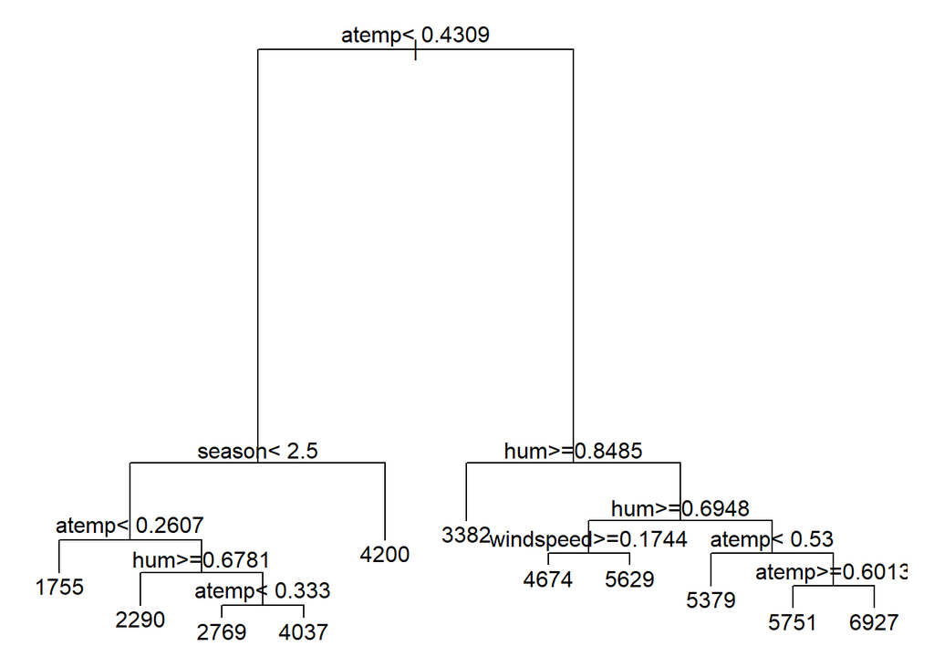

```r
#CART
par(mar=c(1,1,1,1))
mod <- rpart(cnt ~ ., data = data, method = "anova")
plot(mod)
text(mod)
```

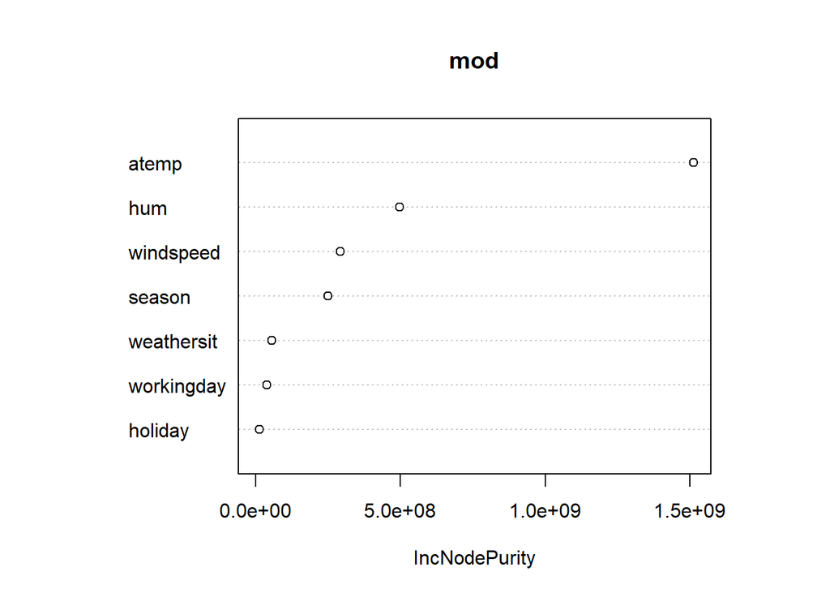

```r
#Looks like atemp, season, hum & windspeed has an influence. Windspeed not so much.
#Holiday, workingday, weathersit does not mean anything according to the tree.

####Bagging####
par(mar=c(5,5,5,5))
set.seed(69)
mod <- randomForest(cnt ~ ., data = data, mtry = 7) #500 replications
varImpPlot(mod) # The same variables  are chosen again
```

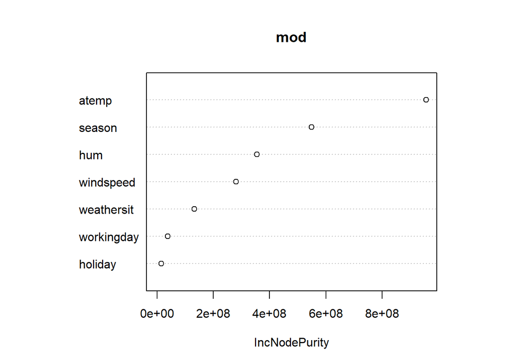

```r
####Random Forest####
mod <- randomForest(cnt ~ ., data = data) #p/3 variables sampled each time, 500
#replications
varImpPlot(mod) #The order of importance changes. Not the bottom ones tho.
```

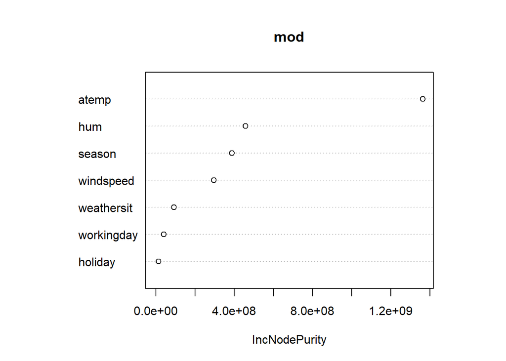

```r
mod <- randomForest(cnt ~ ., data = data, mtry = 5)
varImpPlot(mod)
```

```r
#Looks like the 4 most important variables are the same each time.

mod <- gbm(cnt ~ ., data = data, n.trees = 10000, interaction.depth = 1,
           shrinkage = 0.01)
```

```
## Distribution not specified, assuming gaussian ...
```

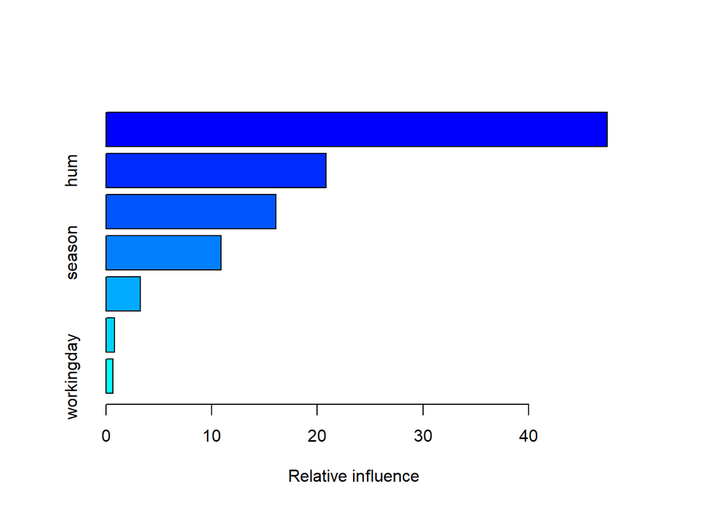

```
##                   var    rel.inf
## atemp           atemp 47.4693226
## hum               hum 20.8397171
## windspeed   windspeed 16.0997001
## season         season 10.8782045
## weathersit weathersit  3.2518170
## holiday       holiday  0.8197164
## workingday workingday  0.6415224
```

```r
summary(mod)
```

```r
mod <- gbm(cnt ~ ., data = data, n.trees = 10000, interaction.depth = 4,
           shrinkage = 0.01)
```

```
## Distribution not specified, assuming gaussian ...
```

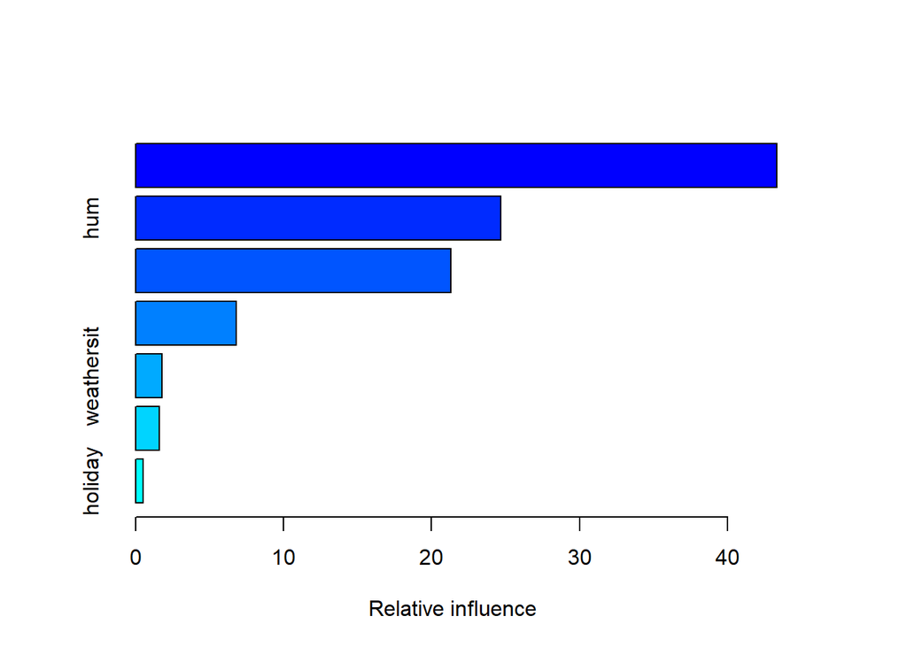

```
##                   var    rel.inf
## atemp           atemp 43.3667315
## hum               hum 24.6619443
## windspeed   windspeed 21.2869103
## season         season  6.7912489
## weathersit weathersit  1.7723777
## workingday workingday  1.5971926
## holiday       holiday  0.5235947
```

```r
summary(mod)
```

```r
#Still the same variables are used each time.
```